# TP2

projet Statistique sous R et Python

Omar THIAM

2024-04-14

# 1 Importations des Bibliothèques

```r
library(haven)
library(tidyverse)
library(here)
library(readxl)
library(sjPlot)
library(ggplot2)
library(expss)
library(labelled)
library(gtsummary)
```

# 2 Importation et inspection de la base

```r
projet_2 <- here::here()
past <- paste0(projet_2,"/Base TP2.xlsx")
projet_2_nd <- read_xlsx(past)
base_tp2 <- data.frame(projet_2_nd)
head(base_tp2)
```

```
##   region departement sexe age sit_mat si_chef_men ethnie occupation formation
## 1      5          53    2  35       1           1     10         22         4
## 2      5          53    1  50       1           2      1          1         1
## 3      2          22    2  35       1           1      1          1         3
## 4      1          12    1  25       1           3      3         22         5
## 5      5          52    2  60       1           1     77          1         3
## 6      3          31    1  36       1           1      3          1        99
##   niveau_alphabs types_varietes types_varietes_1 types_varietes_2
## 1             NA              2                0                1
## 2              0              1                1                0
## 3             NA              1                1                0
## 4             NA              1                1                0
## 5             NA              1                1                0
## 6             NA            1 2                1                1
##               criteres_var criteres_var_1 criteres_var_2 criteres_var_3
```

[output cut: 27 more lines]

Pour connaitre la dimension de la base projet_2, il est possible d’utilisé les fonctions comme **dim** ou **str**.

```r
dim(base_tp2) # donne respectivement le nombre de ligne et de colonne
```

```
## [1] 53 30
```

```r
view(base_tp2)
```

Le nombre d’individus dans la base de données *base_tp2* est de 53, de meme le nombre de variables est de 30.

**NB** : la fonction *str* donne les caractéristiques générales de la base (des variables).

```r
str(base_tp2)
```

```
## 'data.frame':    53 obs. of  30 variables:
##  $ region          : num  5 5 2 1 5 3 3 2 2 4 ...
##  $ departement     : num  53 53 22 12 52 31 32 22 22 41 ...
##  $ sexe            : num  2 1 2 1 2 1 2 1 1 1 ...
##  $ age             : num  35 50 35 25 60 36 25 56 55 80 ...
##  $ sit_mat         : num  1 1 1 1 1 1 1 1 1 1 ...
##  $ si_chef_men     : num  1 2 1 3 1 1 3 2 2 2 ...
##  $ ethnie          : num  10 1 1 3 77 3 3 1 1 2 ...
##  $ occupation      : num  22 1 1 22 1 1 15 1 1 1 ...
##  $ formation       : num  4 1 3 5 3 99 1 1 1 1 ...
##  $ niveau_alphabs  : num  NA 0 NA NA NA NA 1 0 0 0 ...
##  $ types_varietes  : chr  "2" "1" "1" "1" ...
##  $ types_varietes_1: num  0 1 1 1 1 1 1 1 0 1 ...
##  $ types_varietes_2: num  1 0 0 0 0 1 0 0 1 0 ...
##  $ criteres_var    : chr  "1 12 13" "1 4 6 7 11 13" "1 5 6" "1 4 6 7 14 15" ...
```

[output cut: 16 more lines]

**Tableau qui resume les valeurs manquantes par variable**

Nous calculons d’abord la somme des valeurs manquantes par colonne avec la fonction colSums. Ensuite nous mettons les valeurs trouvées dans la variable nbr_NA.

```r
# Calculer le nombre de valeurs manquantes par colonne (variable)
nbr_NA <- colSums(is.na(base_tp2))
```

Nous créons ensuite un dataframe pour y créer les colonnes Nbr_NA et pourcentage_NA qui affichent chacune le nombre de valeurs manquantes par colonne et leur pourcentage.

```r
# Créer un data frame résumant les valeurs manquantes
data_NA <- data.frame(
  Nbr_NA = nbr_NA,
  Pourcentage_NA =100* nbr_NA/nrow(base_tp2)
)
data_NA
```

```
##                  Nbr_NA Pourcentage_NA
## region                0         0.0000
## departement           0         0.0000
## sexe                  0         0.0000
## age                   0         0.0000
## sit_mat               0         0.0000
## si_chef_men           0         0.0000
## ethnie                0         0.0000
## occupation            0         0.0000
## formation             0         0.0000
## niveau_alphabs       13        24.5283
## types_varietes        0         0.0000
## types_varietes_1      0         0.0000
## types_varietes_2      0         0.0000
## criteres_var          0         0.0000
## criteres_var_1        0         0.0000
## criteres_var_2        0         0.0000
## criteres_var_3        0         0.0000
## criteres_var_4        0         0.0000
## criteres_var_5        0         0.0000
## criteres_var_6        0         0.0000
## criteres_var_7        0         0.0000
## criteres_var_8        0         0.0000
## criteres_var_9        0         0.0000
## criteres_var_10       0         0.0000
## criteres_var_11       0         0.0000
## criteres_var_12       0         0.0000
## criteres_var_13       0         0.0000
## criteres_var_14       0         0.0000
## criteres_var_15       0         0.0000
## criteres_var_16       0         0.0000
```

Nous affichons enfin les résultats avec la fonction kabke de knitr.

```r
# Afficher le tableau
knitr::kable(data_NA,
    align = c("c", "c", "c"), caption =
      "Valeurs manquantes par colonne")
```

[output not shown]

La seule variable contenant des valeurs manquantes est *niveau_alphabs*.

*Recherches de valeurs aberrantes*

Pour preuve

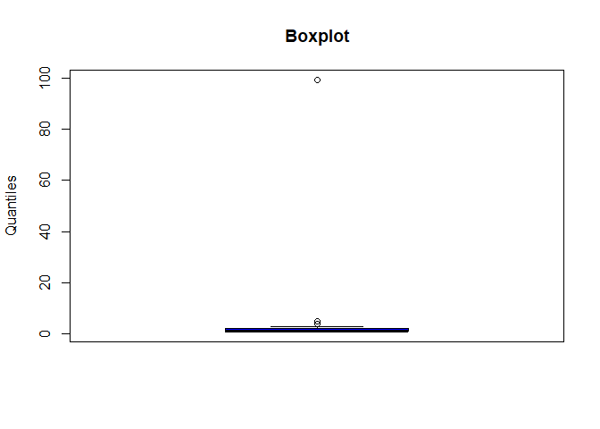

```r
boxplot(base_tp2$formation, col = c("blue"),main = "Boxplot", ylab =
              "Quantiles")
```

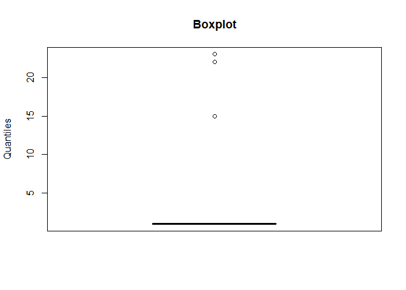

```r
boxplot(base_tp2$occupation, col = c("blue"),main = "Boxplot", ylab =
              "Quantiles")
```

*Correction des valeurs aberrantes*

```r
base_tp2$occupation <-dplyr::recode(base_tp2$occupation,'1'='1',
                                                '15'='5',
                                                '22'='2',
                                                 '23'='3')

base_tp2$types_varietes <-dplyr::recode(base_tp2$types_varietes,'1 2'='1')
```

# 3 Recodage et labelisation

On cherche d’acord les noms de variables dans la base

```r
colnames(base_tp2)
```

```
##  [1] "region"           "departement"      "sexe"             "age"
##  [5] "sit_mat"          "si_chef_men"      "ethnie"           "occupation"
##  [9] "formation"        "niveau_alphabs"   "types_varietes"   "types_varietes_1"
## [13] "types_varietes_2" "criteres_var"     "criteres_var_1"   "criteres_var_2"
## [17] "criteres_var_3"   "criteres_var_4"   "criteres_var_5"   "criteres_var_6"
## [21] "criteres_var_7"   "criteres_var_8"   "criteres_var_9"   "criteres_var_10"
## [25] "criteres_var_11"  "criteres_var_12"  "criteres_var_13"  "criteres_var_14"
## [29] "criteres_var_15"  "criteres_var_16"
```

```r
# View(base_tp2)
```

## 3.1 labelisation

```r
base_tp2 <- expss::apply_labels(base_tp2,
          region="region",
          departement="departement",
          sexe="sexe",
          age="Age",
          sit_mat="Situation matrimoniale",
          si_chef_men="Statut dans le ménage",
          ethnie="Ethnie",
          occupation="Occupation",
          formation="Formation",
          niveau_alphabs="Niveau d'alphabétisation",
          # types_varietes="Quelles variétés    utilisez-vous pour la production de sésame ? ",
          # types_varietes_1="",
          types_varietes_2="",
          criteres_var="Quels sont les critères de choix des variétés de sésame ?",
          criteres_var_1="",
          criteres_var_2="",
          criteres_var_3="",
          criteres_var_4="",
          criteres_var_5="",
          criteres_var_6="",
          criteres_var_7="",
          criteres_var_8="",
          criteres_var_9="",
          criteres_var_10="",
          criteres_var_11="",
          criteres_var_12="",
          criteres_var_13="",
          criteres_var_14="",
          criteres_var_15="",
          criteres_var_16=""
          )
```

## 3.2 Recodage

*Variable sexe*

```r
base_tp2$sexe <-dplyr::recode(base_tp2$sexe,  '1'='Homme',
                                              '2'='Femme')
```

*Variable sit_mat*

```r
base_tp2 <- base_tp2 %>%
  mutate(sit_mat = case_when(
    sit_mat == 1 ~ "Marié(e)",
    sit_mat == 3 ~ "Veuf(ve)",
    sit_mat == 4 ~ "Divorcé(e)",
    sit_mat == 5 ~ "Séparé(e)",
    sit_mat == 6 ~ "Célibataire",
    TRUE ~ "NA"  # Pour toutes les autres valeurs non spécifiées
  ))
```

*Variable si_chef_men*

```r
base_tp2 <- base_tp2 %>%
  mutate(si_chef_men = case_when(
    si_chef_men == 1 ~ "femme du chef de ménage",
    si_chef_men == 3 ~ "chef de ménage",
    si_chef_men == 4 ~ "fils-fille du chef de ménage",
    si_chef_men == 5 ~ "Autres",
    TRUE ~ "NA"  # Pour toutes les autres valeurs non spécifiées
  ))
```

*Variable ethnie*

```r
# Variable ethnie

base_tp2 <- base_tp2 %>%
  mutate(ethnie = case_when(
    ethnie == 1 ~ "Wolof",
    ethnie == 2 ~ "Pulaar/Toucouleur",
    ethnie == 3 ~ "Sérére",
    ethnie == 4 ~ "Mandika/Bambara",
    ethnie == 5 ~ "Soninké",
    ethnie == 6 ~ "Diola",
    ethnie == 7 ~ "Manjack",
    ethnie == 8 ~ "Bainouk",
    ethnie == 9 ~ "Maures",
    ethnie == 10 ~ "Balante",
    TRUE ~ "NA"  # Pour toutes les autres valeurs non spécifiées
  ))
```

*Variable occupation*

```r
base_tp2 <- base_tp2 %>%
  mutate(occupation = case_when(
    occupation == 1 ~ "Agriculture, Elevage Sylviculture, Pêche",
    occupation == 2 ~ "Activités extractives",
    occupation == 3 ~ "Activités de fabrication (Artisanat)",
    occupation == 4 ~ "Activité de transformation",
    occupation == 5 ~ "Production et distribution d'électricité et de gaz",
    occupation == 16 ~ "Production et distribution d'eau, assainissement, traitement des déchets et dépollution",
    TRUE ~ "NA"  # Pour toutes les autres valeurs non spécifiées
  ))
```

*Variable formation*

```r
base_tp2 <- base_tp2 %>%
  mutate(formation = case_when(
    formation == 1 ~ "Non scolarisé",
    formation == 2 ~ "Élémentaire",
    formation == 3 ~ "Moyen",
    formation == 4 ~ "Secondaire",
    formation == 5 ~ "Licence",
    formation == 6 ~ "Master",
    formation == 7 ~ "Doctorat",
    formation == 99 ~ "Ne sait pas",
    TRUE ~ "NA"  # Pour toutes les autres valeurs non spécifiées
  ))
```

*Variable niveau_alphabs*

```r
base_tp2 <- base_tp2 %>%
  mutate(niveau_alphabs = case_when(
    niveau_alphabs == 0 ~ "Sans niveau",
    niveau_alphabs == 1 ~ "Sait lire dans une langue",
    niveau_alphabs == 2 ~ "Sait lire et écrire dans une langue",
    TRUE ~ "NA"  # Pour toutes les autres valeurs non spécifiées
  ))
```

*Variable types_varietes*

```r
base_tp2 <- base_tp2 %>%
  mutate(types_varietes = case_when(
    types_varietes == 1 ~ "traditionnelles",
    types_varietes == 2 ~ "Améliorées",
    TRUE ~ 'NA'  # Pour toutes les autres valeurs non spécifiées
  ))
```

*Variable types_varietes_1*

```r
base_tp2 <- base_tp2 %>%
  mutate(types_varietes_1 = case_when(
    types_varietes_1 == 1 ~ "traditionnelles",
    TRUE ~ 'NA'  # Pour toutes les autres valeurs non spécifiées
  ))
```

*Variable types_varietes_2*

```r
base_tp2 <- base_tp2 %>%
  mutate(types_varietes_2 = case_when(
    types_varietes_2 == 1 ~ "Améliorées",
    TRUE ~ 'NA'  # Pour toutes les autres valeurs non spécifiées
  ))
```

pour ne pas à repeter le travail, je change le nom

```r
projet_2<-copy(base_tp2)
```

# 4 Analyses descriptives

## 4.1 Analyses univariees

```r
univarie <- function(data, var, include_na = TRUE) {
  if (!is.data.frame(data)) {
    stop("la base de données n'est pas un dataframe")
  }
  nom <- deparse(substitute(var))#Ici nous avons recuperer uniquement le nom de la variable pour éviter qu'au niveau de nos condition if ça renvoi un vecteur et par conséquent y'aura des erreur
  if (!nom %in% names(data)) {
    stop("cette variable n'existe pas dans la base")
  }

  # if (!include_na) {
  #   data <- na.omit(data)#supprimer les ligne qui ont des NA
  # }

  # Calcul des statistiques descriptives
  summary_stats <- summary(data[[nom]])
  # Tracé des fréquences
  graphe <- sjPlot::plot_frq(data, coord.flip = TRUE, nom, show.na = include_na)
  show(graphe)
  return(summary_stats)
}
```

```r
colnames(projet_2)
```

```
##  [1] "region"           "departement"      "sexe"             "age"
##  [5] "sit_mat"          "si_chef_men"      "ethnie"           "occupation"
##  [9] "formation"        "niveau_alphabs"   "types_varietes"   "types_varietes_1"
## [13] "types_varietes_2" "criteres_var"     "criteres_var_1"   "criteres_var_2"
## [17] "criteres_var_3"   "criteres_var_4"   "criteres_var_5"   "criteres_var_6"
## [21] "criteres_var_7"   "criteres_var_8"   "criteres_var_9"   "criteres_var_10"
## [25] "criteres_var_11"  "criteres_var_12"  "criteres_var_13"  "criteres_var_14"
## [29] "criteres_var_15"  "criteres_var_16"
```

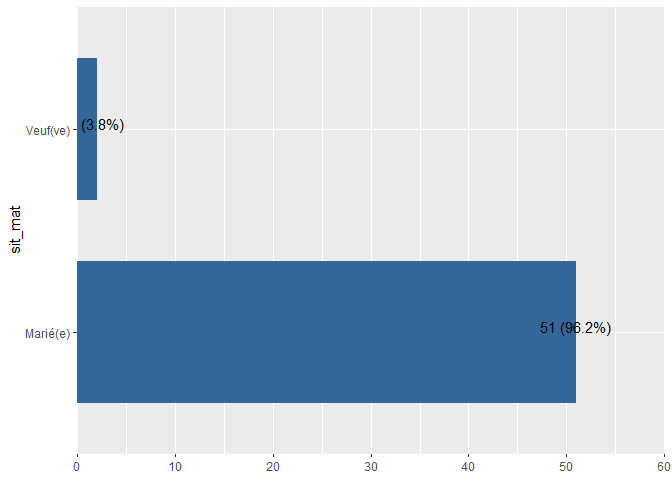

```
##    Length     Class      Mode
##        53 character character
```

```r
univarie(projet_2,sit_mat)
```

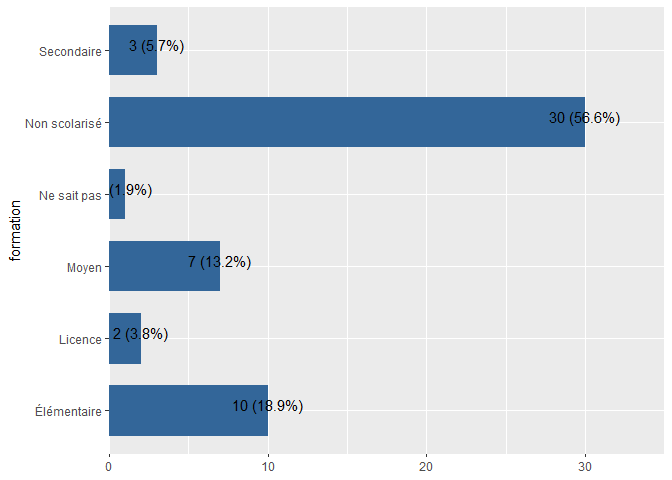

```
##    Length     Class      Mode
##        53 character character
```

```r
univarie(projet_2,formation)
```

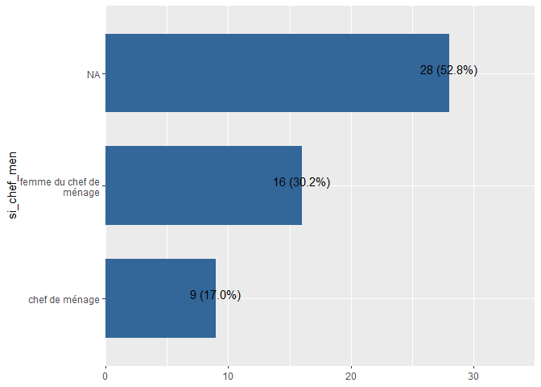

```
##    Length     Class      Mode
##        53 character character
```

```r
univarie(projet_2,si_chef_men)
```

Ces pourcentages suggèrent que dans cet échantillon, une proportion relativement faible est composée de chefs de ménage (17%) et de femmes du chef de ménage (30%), tandis que la majorité des réponses (53%) sont non applicables (NA).

```r
univarie_2 <- function(data, variable){
  obj <- data[[variable]]

  ####### Variable quantitative ########
  if (is.numeric(obj)){
    #### Statistiques descriptives ######
    summary_table <- projet %>%
      select(variable) %>%
        gtsummary::tbl_summary(
          type = variable ~ "continuous2", #spécifie le type de résumé
          statistic = list(variable ~ c("{mean}", "{sd}", "{median}", "{min}, {max}", "{p25}; {p75}","{N_miss}; {p_miss}")),
          digits = variable ~ 2 #précisez le nombre de décimales pour l'arrondi
           )%>%
           gtsummary::bold_labels() # Mettre en gras les étiquettes de la variable
        summary_table
    ###### Histogramme #######
    hist(obj,
      col = c("blue"),
      main = paste("Histogramme"),
      ylab = "Frequence",
      xlab = variable)

    ###### Boite à moustache #######
    boxplot(obj, col = c("blue"),main = "Boxplot", ylab =
              "Quantiles")

  ####### Variable qualitative ########
   }
  else if (!is.numeric(obj)){
    summary_table <- projet_2 %>%
      select(variable) %>%
      gtsummary::tbl_summary(
        statistic = list(variable ~ "{n} ({p}%)"),
        digits = variable ~ 2 #précisez le nombre de décimales pour l'arrondi
      )%>%
      gtsummary::bold_labels() # Mettre en gras les étiquettes de la variable
    summary_table
    barplot(table(obj), main="Diagramme en barre",
        xlab=variable,
        col="blue")
  }
}
```

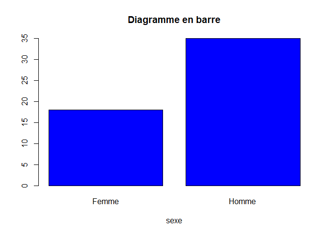

```r
univarie_2(projet_2,"sexe")
```

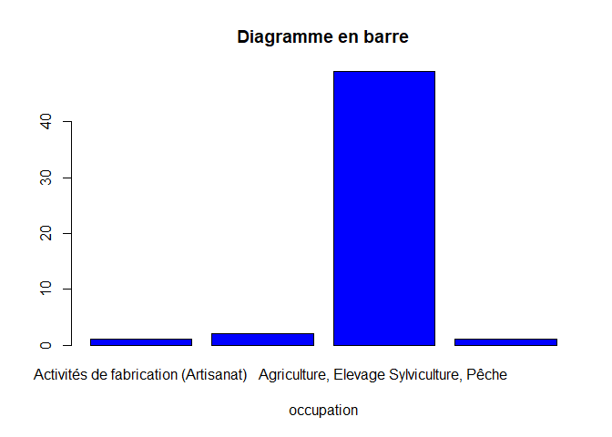

```r
univarie_2(projet_2,"occupation")
```

Dans cet échantillon, les hommes représentent 66% des participants, tandis que les femmes ne représentent que 34%.

## 4.2 Analyses bivariees

```r
bivarie <- function(data, variable1,variable2) {
      data %>%
             tbl_summary(
                  by = variable2,
                  include = variable1,
                  statistic = all_categorical() ~ "{p}%",
                  digits = all_categorical() ~ 2)
}
```

```r
colnames(projet_2)
```

```
##  [1] "region"           "departement"      "sexe"             "age"
##  [5] "sit_mat"          "si_chef_men"      "ethnie"           "occupation"
##  [9] "formation"        "niveau_alphabs"   "types_varietes"   "types_varietes_1"
## [13] "types_varietes_2" "criteres_var"     "criteres_var_1"   "criteres_var_2"
## [17] "criteres_var_3"   "criteres_var_4"   "criteres_var_5"   "criteres_var_6"
## [21] "criteres_var_7"   "criteres_var_8"   "criteres_var_9"   "criteres_var_10"
## [25] "criteres_var_11"  "criteres_var_12"  "criteres_var_13"  "criteres_var_14"
## [29] "criteres_var_15"  "criteres_var_16"
```

```r
tb1 = bivarie(projet_2,"formation","sexe")
tb1
```

| **Characteristic** | **Femme**, N = 18<sup>1</sup> | **Homme**, N = 35<sup>1</sup> |
| --- | --- | --- |
| formation |  |  |
| Élémentaire | 11.11% | 22.86% |
| Licence | 0.00% | 5.71% |
| Moyen | 11.11% | 14.29% |
| Ne sait pas | 0.00% | 2.86% |
| Non scolarisé | 72.22% | 48.57% |
| Secondaire | 5.56% | 5.71% |

<sup>1</sup> %

Ce que nous pouvons observer ici, c’est que la catégorie “Non scolarisé” est la plus courante chez les deux groupes, mais elle est plus fréquente chez les femmes (72.22%) que chez les hommes (48.57%). D’autre part, la catégorie “Élémentaire” est également plus fréquente chez les hommes (22.86%) que chez les femmes (11.11%).

```r
tb2 = bivarie(projet_2,"occupation","sexe")
tb2
```

| **Characteristic** | **Femme**, N = 18<sup>1</sup> | **Homme**, N = 35<sup>1</sup> |
| --- | --- | --- |
| occupation |  |  |
| Activités de fabrication (Artisanat) | 5.56% | 0.00% |
| Activités extractives | 5.56% | 2.86% |
| Agriculture, Elevage Sylviculture, Pêche | 83.33% | 97.14% |
| Production et distribution d'électricité et de gaz | 5.56% | 0.00% |

<sup>1</sup> %

Il est clair que la majorité des femmes (83.33%) sont impliquées dans l’agriculture, l’élevage, la sylviculture et la pêche, tandis que la majorité des hommes (97.14%) sont également impliqués dans ces activités.

Il y a des différences subtiles dans d’autres catégories. Par exemple, les femmes sont légèrement plus impliquées dans les activités de fabrication et d’extraction que les hommes, bien que les pourcentages restent assez faibles dans l’ensemble.

```r
tb3 = bivarie(projet_2,"niveau_alphabs","sexe")
tb3
```

| **Characteristic** | **Femme**, N = 18<sup>1</sup> | **Homme**, N = 35<sup>1</sup> |
| --- | --- | --- |
| niveau_alphabs |  |  |
| NA | 16.67% | 28.57% |
| Sait lire dans une langue | 22.22% | 5.71% |
| Sait lire et écrire dans une langue | 0.00% | 22.86% |
| Sans niveau | 61.11% | 42.86% |

<sup>1</sup> %

Chez les femmes, la majorité (61.11%) se trouve dans la catégorie “Sans niveau”, suivie de “Sait lire dans une langue” (22.22%). Chez les hommes, bien que la catégorie “Sans niveau” soit toujours la plus représentée (42.86%), il y a une proportion significative qui sait lire et écrire dans une langue (22.86%). Il est également important de noter que le pourcentage de données non disponibles (NA) est plus élevé chez les hommes que chez les femmes (28.57% contre 16.67%).

```r
tb4 = bivarie(projet_2,"niveau_alphabs","sit_mat")
tb4
```

| **Characteristic** | **Marié(e)**, N = 51<sup>1</sup> | **Veuf(ve)**, N = 2<sup>1</sup> |
| --- | --- | --- |
| niveau_alphabs |  |  |
| NA | 25.49% | 0.00% |
| Sait lire dans une langue | 11.76% | 0.00% |
| Sait lire et écrire dans une langue | 15.69% | 0.00% |
| Sans niveau | 47.06% | 100.00% |

<sup>1</sup> %

Il est clair que pour les personnes mariées, la plupart se trouvent dans la catégorie “Sans niveau” (47.06%), suivie de la catégorie “NA” (25.49%). Il y a aussi une proportion notable qui sait lire et écrire dans une langue spécifique (15.69%).

En revanche, pour les veufs ou veuves, toutes les réponses sont regroupées dans la catégorie “Sans niveau”. Il n’y a aucune donnée dans les autres catégories.

```r
tb4 = bivarie(projet_2,"occupation","sit_mat")
tb4
```

| **Characteristic** | **Marié(e)**, N = 51<sup>1</sup> | **Veuf(ve)**, N = 2<sup>1</sup> |
| --- | --- | --- |
| occupation |  |  |
| Activités de fabrication (Artisanat) | 1.96% | 0.00% |
| Activités extractives | 3.92% | 0.00% |
| Agriculture, Elevage Sylviculture, Pêche | 92.16% | 100.00% |
| Production et distribution d'électricité et de gaz | 1.96% | 0.00% |

<sup>1</sup> %

On peut observer que pour les personnes mariées, la grande majorité est impliquée dans l’agriculture, l’élevage, la sylviculture et la pêche (92.16%). Il y a également une petite proportion impliquée dans les activités de fabrication et extractives.

En revanche, pour les veufs ou veuves, toutes les réponses sont regroupées dans la catégorie “Agriculture, Elevage Sylviculture, Pêche”. Il n’y a aucune donnée dans les autres catégories.